# Practical1

Gia Bao hoang

2023-03-02

# Set up

Load the data set

```r
data(Rubber, package = "MASS")
Rubber
```

```
##    loss hard tens
## 1   372   45  162
## 2   206   55  233
## 3   175   61  232
## 4   154   66  231
## 5   136   71  231
## 6   112   71  237
## 7    55   81  224
## 8    45   86  219
## 9   221   53  203
## 10  166   60  189
## 11  164   64  210
## 12  113   68  210
## 13   82   79  196
## 14   32   81  180
```

[output cut: 16 more lines]

# Plot

Plot hard against loss

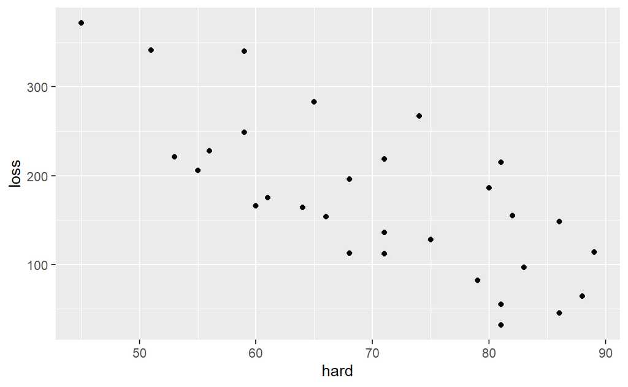

```r
ggplot(Rubber,
       aes(hard, loss)
       ) +
  geom_point()
```

Plot tens against loss

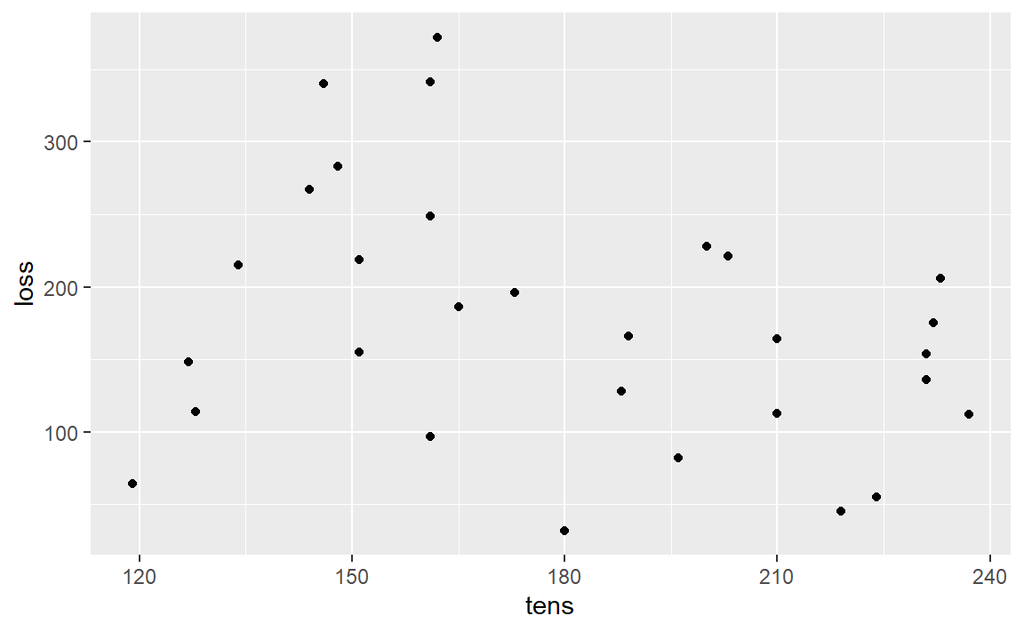

```r
ggplot(Rubber,
       aes(tens, loss)
       ) +
  geom_point()
```

SIde by side comparision with trendline

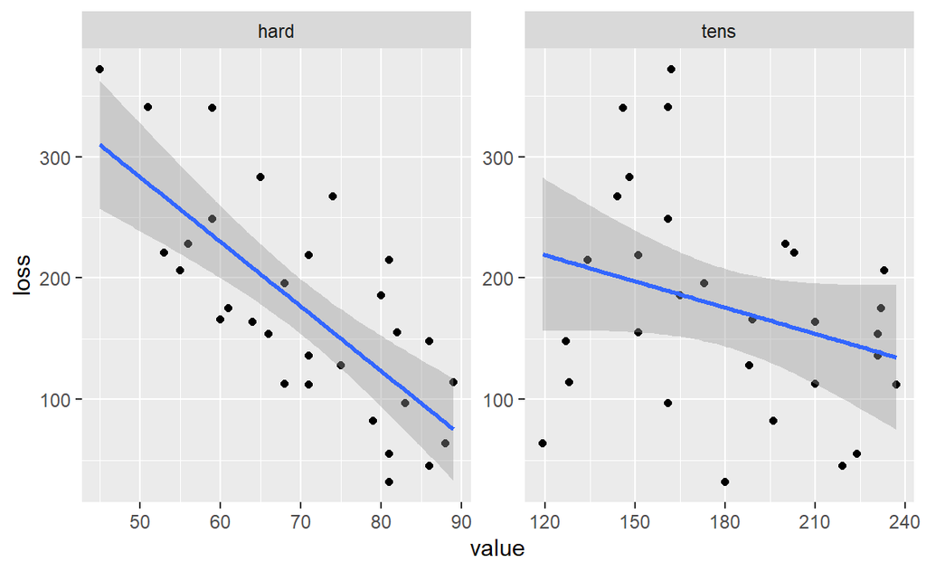

```r
Rubber %>%
  pivot_longer(-loss) %>%
  ggplot(aes(value, loss)) +
  geom_point() +
  facet_wrap(~name, scales = "free") +
  geom_smooth(method = lm)
```

# Model

Fit the multiple linear regression
$${E}(\texttt{loss}_i)=\beta_0+\beta_1\times\texttt{hard}_i+\beta_2\times\texttt{tens}_i$$

```r
rubber_lm <- lm(loss ~ hard + tens, data = Rubber)
summary(rubber_lm)
```

```
##
## Call:
## lm(formula = loss ~ hard + tens, data = Rubber)
##
## Residuals:
##     Min      1Q  Median      3Q     Max
## -79.385 -14.608   3.816  19.755  65.981
##
## Coefficients:
##             Estimate Std. Error t value Pr(>|t|)
## (Intercept) 885.1611    61.7516  14.334 3.84e-14 ***
## hard         -6.5708     0.5832 -11.267 1.03e-11 ***
## tens         -1.3743     0.1943  -7.073 1.32e-07 ***
## ---
## Signif. codes:  0 '***' 0.001 '**' 0.01 '*' 0.05 '.' 0.1 ' ' 1
##
## Residual standard error: 36.49 on 27 degrees of freedom
## Multiple R-squared:  0.8402, Adjusted R-squared:  0.8284
## F-statistic:    71 on 2 and 27 DF,  p-value: 1.767e-11
```

Interpret the output: - The least square estimate of $\beta_1$ is $\hat\beta_1=-6.5708$. The interpretation of this estimate is that an increase of 1 unit of hardness, with tensile strength kept constant, would reduce the rate of abrasion by 6.5708 grams per hour. - The least square estimate of $\beta_2$ is $\hat\beta_2=-1.3743$. The interpretation of this estimate is that an increase of 1 unit of tensil strength, with hardness kept constant, would reduce the rate of abrasion by 1.3742 grams per hour

# Verify model

Verify the assumption of linear regression

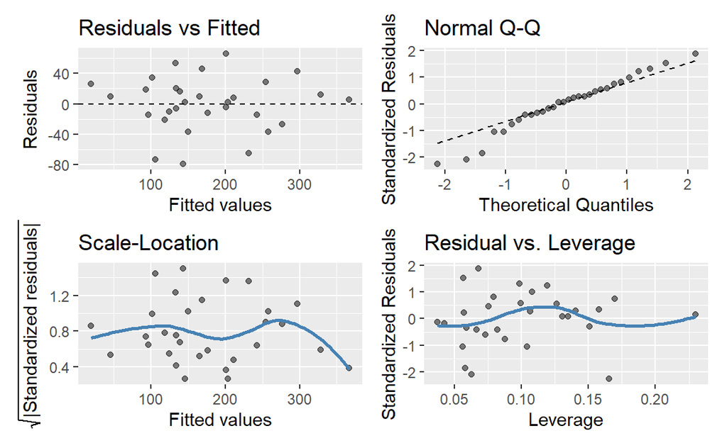

```r
gglm(rubber_lm)
```

**Linearity** - Random scatter with a slight curvature near the end points -> satisfied

**Homocedasticity** - The spread about the zero line is roughly constant -> satisfied

**Normality** - There are departure from normality in the lower tail. However, the rest of the data is closed to normally distributed -> satisfied

# Prediction

Predict loss for the following points

```r
n_pts <- tibble(
  hard = c(50, 65),
  tens = c(200, 190)
)
n_pts
```

```
## # A tibble: 2 × 2
##    hard  tens
##   <dbl> <dbl>
## 1    50   200
## 2    65   190
```

```r
predict(rubber_lm)
```

```
##         1         2         3         4         5         6         7         8
## 366.83526 203.55082 165.50016 134.02032 101.16617  92.92030  45.07805  19.09546
##         9        10        11        12        13        14        15        16
## 257.92184 231.16639 176.02253 149.73921  96.70044 105.54777 242.33228 200.58874
##        17        18        19        20        21        22        23        24
## 133.97826 118.51804 143.38498 276.21795 211.11111 132.73328 138.83198 124.44535
##        25        26        27        28        29        30
## 328.78459 296.83263 254.65903 201.01880 168.76611 145.53215
```

```r
predict(rubber_lm, newdata = n_pts)
```

```
##        1        2
## 281.7573 196.9379
```

Calculate 95% CI and PI for the new points

```r
predict(rubber_lm, newdata = n_pts, interval = "confidence")
```

```
##        fit      lwr      upr
## 1 281.7573 254.8762 308.6383
## 2 196.9379 181.8821 211.9938
```

```r
predict(rubber_lm, newdata = n_pts, interval = "prediction")
```

```
##        fit      lwr      upr
## 1 281.7573 202.2079 361.3066
## 2 196.9379 120.5692 273.3067
```

# Matrix

The design matrix of the model

```r
x <- model.matrix(rubber_lm)
x
```

```
##    (Intercept) hard tens
## 1            1   45  162
## 2            1   55  233
## 3            1   61  232
## 4            1   66  231
## 5            1   71  231
## 6            1   71  237
## 7            1   81  224
## 8            1   86  219
## 9            1   53  203
## 10           1   60  189
## 11           1   64  210
## 12           1   68  210
## 13           1   79  196
## 14           1   81  180
```

[output cut: 18 more lines]

Assign the response variable `loss` to a variable Y

```r
Y <- Rubber$loss
Y
```

```
##  [1] 372 206 175 154 136 112  55  45 221 166 164 113  82  32 228 196 128  97  64
## [20] 249 219 186 155 114 341 340 283 267 215 148
```

Calculate $\hat\beta=(X^TX)^{-1}X^TY$

```r
beta_hat <- solve(t(x) %*% x) %*% t(x) %*% Y
beta_hat
```

```
##                   [,1]
## (Intercept) 885.161109
## hard         -6.570830
## tens         -1.374312
```

Calculate $\hat{\boldsymbol{\eta}}=X\hat{\boldsymbol{\beta}}$

```r
eta <- x %*% beta_hat
eta
```

```
##         [,1]
## 1  366.83526
## 2  203.55082
## 3  165.50016
## 4  134.02032
## 5  101.16617
## 6   92.92030
## 7   45.07805
## 8   19.09546
## 9  257.92184
## 10 231.16639
## 11 176.02253
## 12 149.73921
## 13  96.70044
## 14 105.54777
```

[output cut: 16 more lines]

Calculate the residual variance, $s^2_e$ directly from the observed and fitted values

```r
n <- nrow(Rubber)
se <- sqrt(sum((Y - eta)^2) / (n - 3))
se
```

```
## [1] 36.48934
```

Calculate the estimated variance matrix for $\hat{\boldsymbol{\beta}}$ using
$$(X^TX)^{-1} \times s^2_e$$
Compare this to the result of the built-in calculation vcov()

```r
vcov(rubber_lm)
```

```
##             (Intercept)         hard        tens
## (Intercept)  3813.25821 -30.01766345 -9.19635018
## hard          -30.01766   0.34010794  0.03390882
## tens           -9.19635   0.03390882  0.03775595
```

```r
res <- solve(t(x) %*% x) * se^2
res
```

```
##             (Intercept)         hard        tens
## (Intercept)  3813.25821 -30.01766345 -9.19635018
## hard          -30.01766   0.34010794  0.03390882
## tens           -9.19635   0.03390882  0.03775595
```